# 2. Dose-Response Data Processing

#### 7.1.2.2 EFM-19

🔍 Zoom In for Details

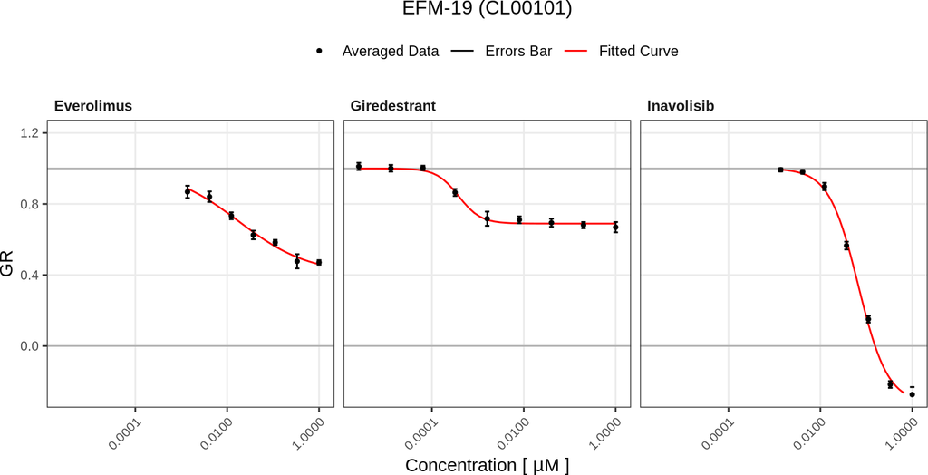

#### 7.1.2.3 MCF-7

🔍 Zoom In for Details

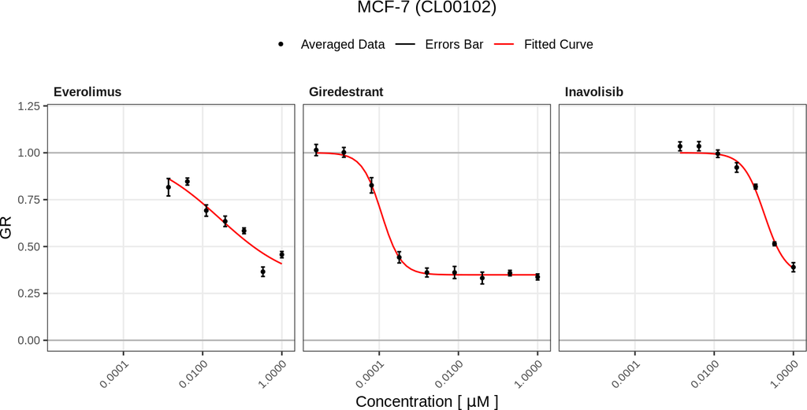

#### 7.1.2.4 T-47D

🔍 Zoom In for Details

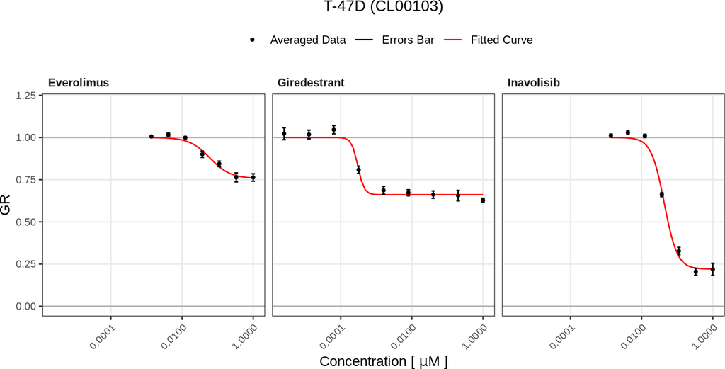

## 7.2 Quality Control - Fitting Precision - Single-Agent Data

This section provides a **quantitative summary of the model’s fitting quality** using two key statistical metrics: R-squared (R²) and Residual Sum of Squares (RSS). The metrics for each drug-cell line combination are displayed as a lollipop plot, which allows for easy comparison across different conditions.

**What to look for:** The lollipop plots allow for a quick comparison of fitting quality.

- **R-squared (R²):** This value represents the “goodness-of-fit.” **A value closer to 1 indicates a better fit**, meaning the model explains a high proportion of the variance in the data. Look for lollipops at the high end of the scale.
- **Residual Sum of Squares (RSS):** This value represents the overall error of the fit. **A lower RSS value indicates a better fit**, with less error between the model and the data. Look for lollipops at the low end of the scale.

```r
cellline_vec <- sort(unique(response_metrics_sa[["CellLineName"]]))
cellline_vec_names <- vapply(cellline_vec, function(i) escape_special_characters(i),
                      FUN.VALUE = character(1))

ls_plt_RV <- pmap(list(cl_name = cellline_vec),
                  plot_fitting_acc,
                  dt_assay = response_metrics_sa,
                  normalization_type = "RV")
names(ls_plt_RV) <- cellline_vec_names
```

```r
ls_plt_GR <- pmap(list(cl_name = cellline_vec),
                  plot_fitting_acc,
                  dt_assay = response_metrics_sa,
                  normalization_type = "GR")
names(ls_plt_GR) <- cellline_vec_names
```

### 7.2.1 Relative Viability

#### 7.2.1.1 CAMA-1

🔍 Zoom In for Details

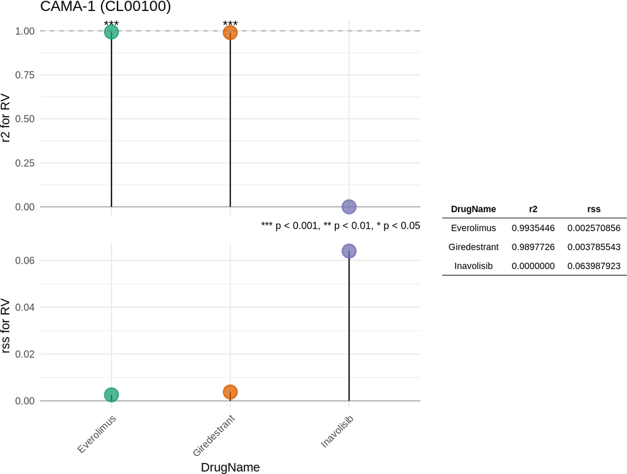

#### 7.2.1.2 EFM-19

🔍 Zoom In for Details

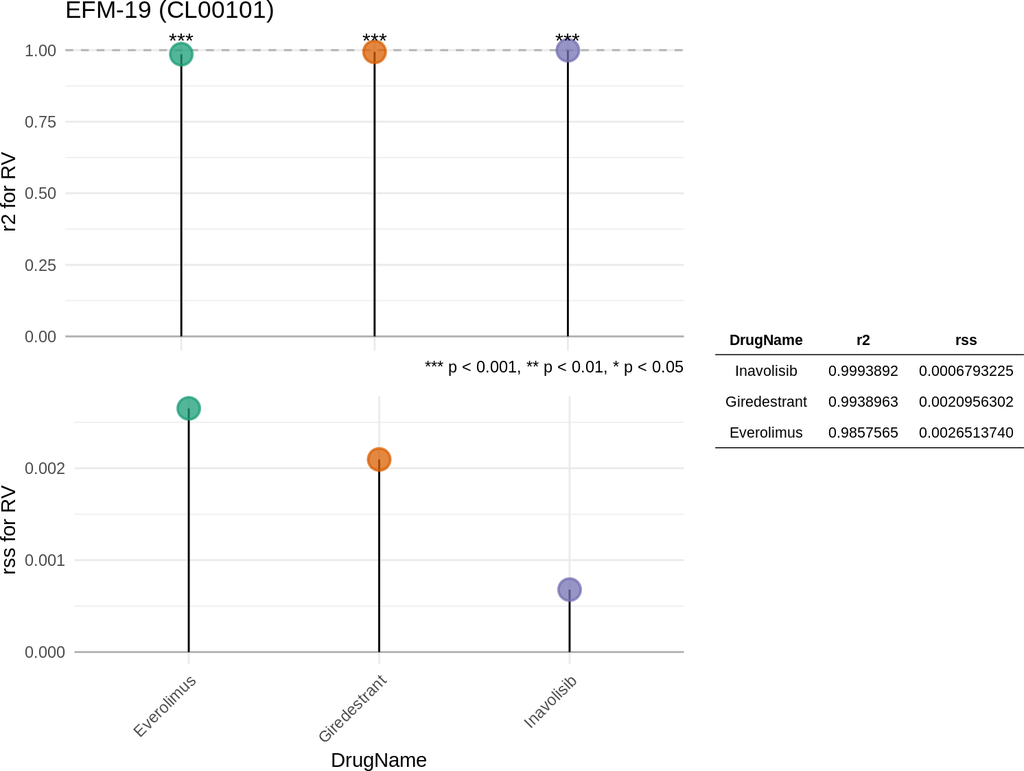

#### 7.2.1.3 MCF-7

🔍 Zoom In for Details

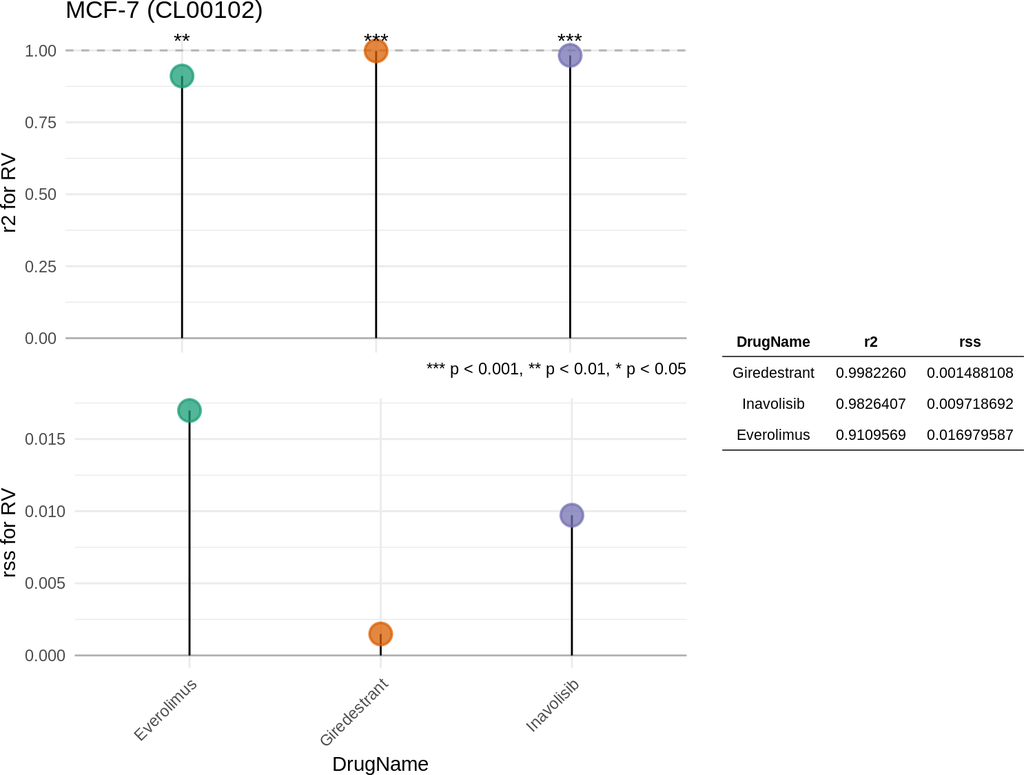

#### 7.2.1.4 T-47D

🔍 Zoom In for Details

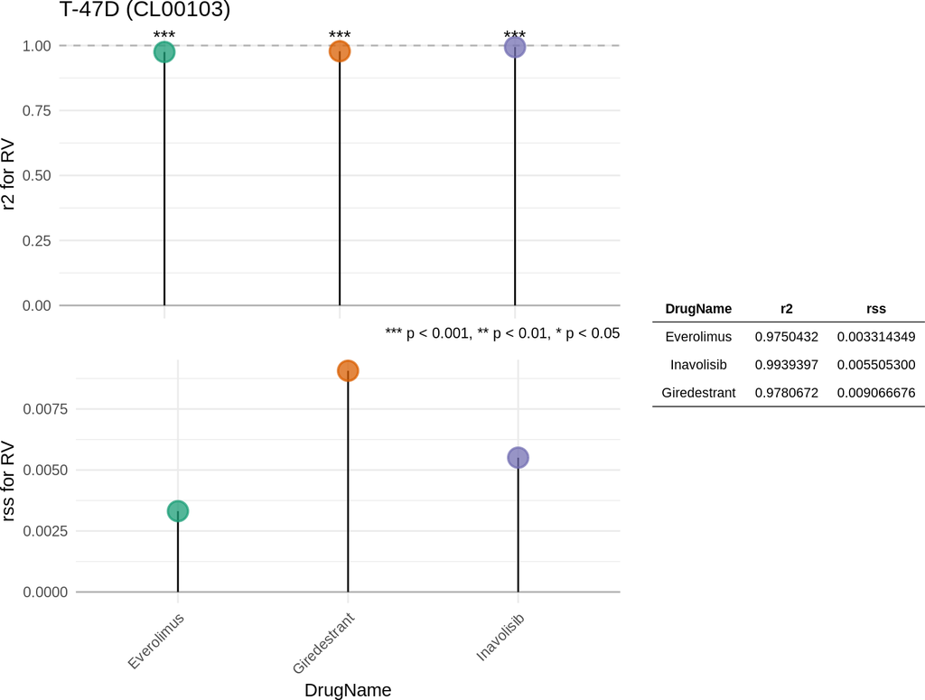

### 7.2.2 GR Value

#### 7.2.2.1 CAMA-1

🔍 Zoom In for Details

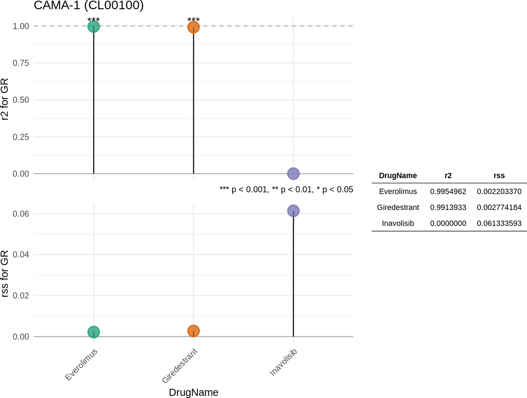

#### 7.2.2.2 EFM-19

🔍 Zoom In for Details

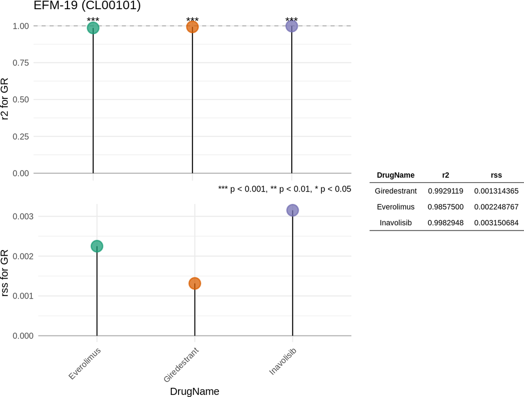

#### 7.2.2.3 MCF-7

🔍 Zoom In for Details

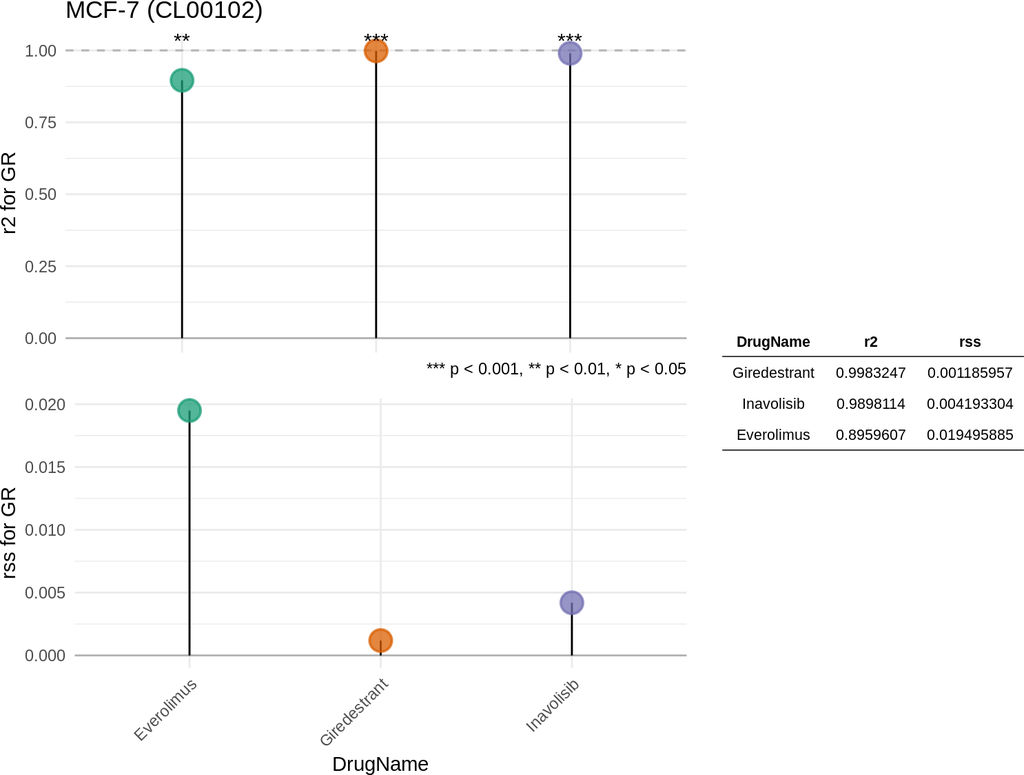

#### 7.2.2.4 T-47D

🔍 Zoom In for Details

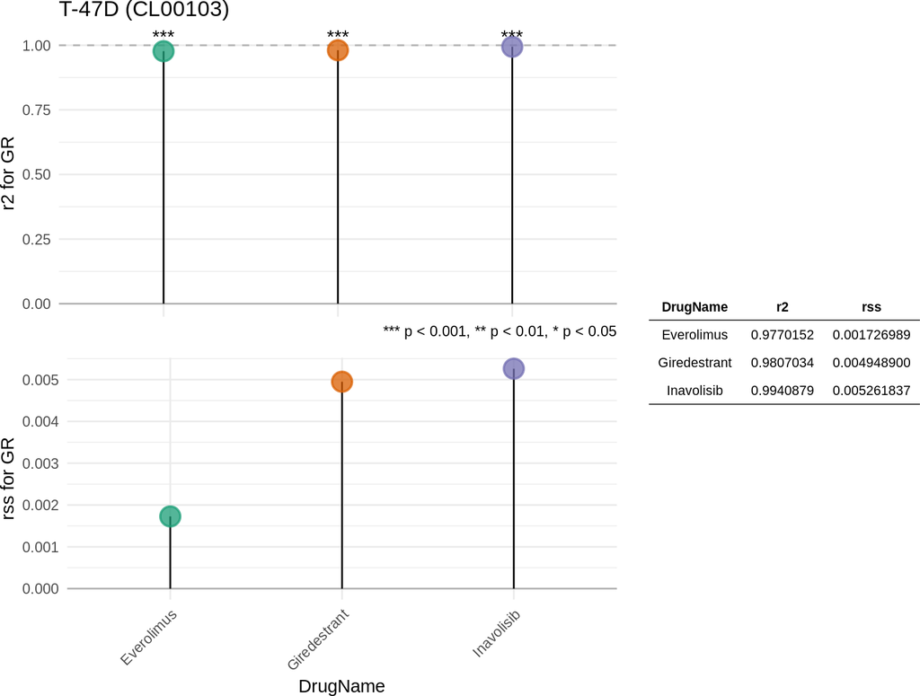

# 8 Assemble and Save Final Results

Finally, all processed data and results are combined into a single `MultiAssayExperiment` (MAE) object. The MAE is a flexible container that holds all `SummarizedExperiment` objects, ensuring all data and metadata are stored together in an organized and accessible format.

```r
mae <- if (exists("se_combo") && !is.null(se_combo)) {
  MultiAssayExperiment(experiments = setNames(list(se_sa, se_combo), c(sa_name, combo_name)))
} else {
  MultiAssayExperiment(experiments = setNames(list(se_sa), c(sa_name)))
}
mae <- standardize_mae(mae)
qs_save(mae, file.path(wd, "gDR_data", "gDR_mae.qs2"))
```

Please note: Steps 5 through 9 can be automatically executed using the runDrugResponseProcessingPipeline function, which handles all stages of the pipeline for all identified data types."

# 9 Conclusion

The data processing and dose-response fitting are complete. The final, comprehensive results are stored in the `MultiAssayExperiment` object located at `gDR_data/gDR_mae.qs2`. This object contains all data layers (raw, normalized, averaged, and metrics) and is ready for downstream biological interpretation and visualization.

### We Value Your Feedback!

Thank you for using gDR! We are always looking to improve, and your feedback is incredibly valuable to us.

[Share feedback or request features on GitHub](https://github.com/gdrplatform/gDRworkshops/issues)

# 10 gDR session info

```r
gdr_sdt <- get_gDR_session_info()
generate_datatable(gdr_sdt)
```

|  | Package | Version |
| --- | --- | --- |
| 1 | gDR | 1.11.3 |
| 2 | gDRcore | 1.11.5 |
| 3 | gDRimport | 1.11.3 |
| 4 | gDRinternal | 1.0.265 |
| 5 | gDRplots | 0.0.108 |
| 6 | gDRutils | 1.11.3 |
| 7 | gDRcomponents | 1.4.123 |
| 8 | gDRin | 0.2.92 |
| 9 | gDRinternalData | 0.0.13 |
| 10 | gDRinternalShiny | 0.0.21 |

[output cut: 6 more lines]